# Introduccion a R

BCRA

Maximo Sangiacomo

Julio 2021

# ¿Por que es importante aprender a usar **R**?

- La programación de rutinas en software específico para la manipulación y análisis de bases de datos permite asegurar procesos homogéneos, documentados, fácilmente auditables, modificables y que pueden ser compartidos entre diferentes usuarios. Ademas, resulta sumamente util para realizar tareas repetitivas generando ganancias de eficiencia.
- Es muy importante realizar anotaciones, tanto para compartir codigo con otro usuario como para mi mismo en el futuro (cuales son los insumos/output, los ¿por que? en casos especificos). **Cmd/Ctrl + Shift + R** para crear secciones en scripts. Sirve para navegar y ser ordenados.

> *A la gloria no se llega por un camino de rosas*. Practicar.

> — [Osvaldo Zubeldia](https://es.wikipedia.org/wiki/Osvaldo_Zubeld%C3%ADa).
- La practica completa nuestra caja de herramientas.
- El desarrollo de un script o programa comienza con una semilla.

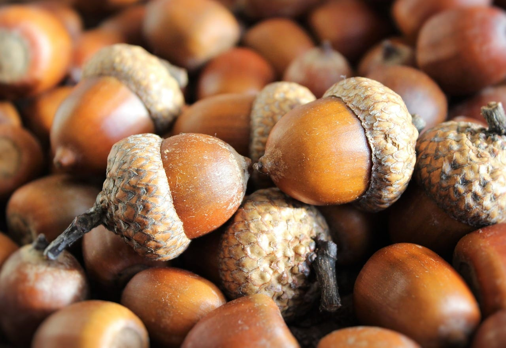

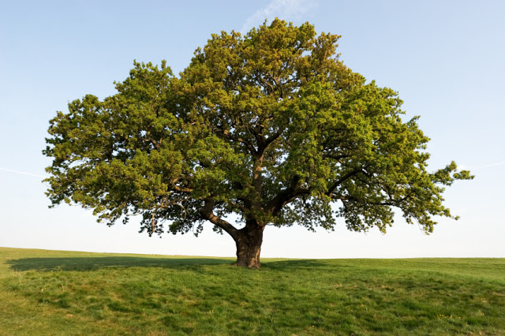

# ¿Para que sirve este curso?

Se van a llevar una caja llena de herramientas y semillas para plantar su propio bosque.

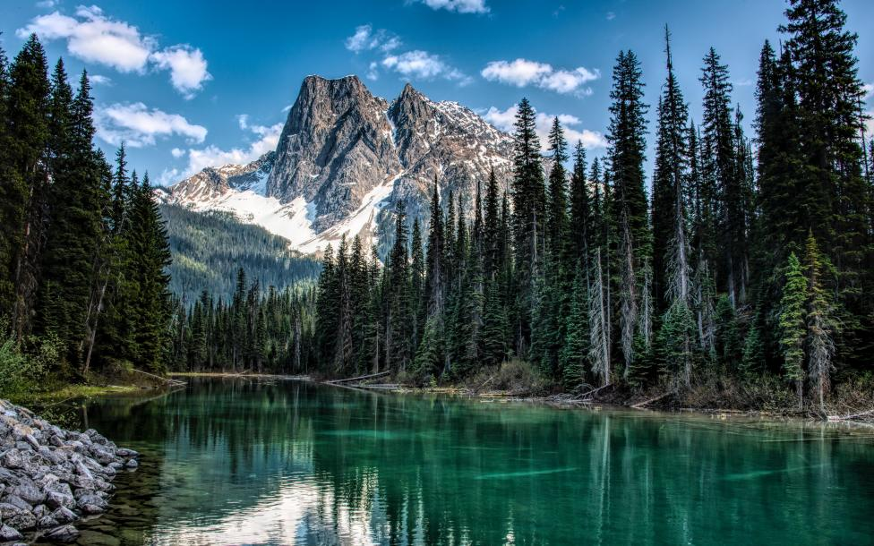

# Primeros pasos en R

> **R** es un lenguaje orientado a **objetos** (vectores, listas, matrices). Si bien al principio puede parecer demasiado complejo, no es asi. De hecho, una característica destacada de R es su flexibilidad.

> *Mientras que un software clasico muestra inmediatamente los resultados de un comando, R los almacena en un objeto, por lo que se puede realizar un análisis sin el resultado desplegado.*

**R** (el motor) puede complementarse con **RStudio** (tablero de instrumentos) que es una IDE (*integrated development environment*) para operar de manera mas amigable (editor con sintaxis y distintos espacios de trabajo). Cada uno se encuentra disponible en (buscar versiones adecuadas al sistema operativo):

1. [R](https://cran.r-project.org/)
2. [RStudio](https://www.rstudio.com/products/rstudio/download/)

Una vez instalados los programas se deben descargar “paquetes” que agregan funcionalidades al paquete que viene incorporado (base).

```r
#Descarga de programa
install.packages('tidyverse')

#Carga de programa antes de utilizarlo en un script
library(tidyverse)
```

Eventualmente se puede utilizar una funcion especifica de un paquete previamente instalado sin cargar el paquete completo. Por ejemplo, si se quiere utilizar la funcion `read_excel()` del paquete `readxl`.

```r
readxl::read_excel()
```

## Tipos de datos

- character/string
- numeric
- factor (variables categoricas, importante para clasificacion)
- integer
- logical
- date

# Aprendiendo a utilizar R

## Ayuda

```r
# Por comandos
?rm #Para poder ver la ayuda el paquete debe estar instalado
help(lm)

# Buscar en la ventana Help de RStudio
```

## Recursos

[R for Beginners](https://education.rstudio.com/learn/beginner/)

[R for Beginners (otro)](https://cran.r-project.org/doc/contrib/Paradis-rdebuts_en.pdf)

[R for Data Science](https://r4ds.had.co.nz/)

[R Cookbook](http://www.cookbook-r.com/)

[R Graphics Cookbook](https://r-graphics.org/)

[Google](https://www.google.com/)

[Paquete EPH](https://github.com/holatam/eph) (usuarios EPH)

## Limpieza de memoria

```r
rm(list = ls()) # Elimina todos los objetos en memoria
gc() # Garbage Collection
```

## Asignacion de valores a un objeto

```r
# nombre_objeto <- valor
x <- 1
x = 5
x
```

```
## [1] 5
```

```r
y = x
y = 4
```

## Operadores

### Aritmeticos

```r
y + x
```

```
## [1] 9
```

```r
y - x
```

```
## [1] -1
```

```r
y * x
```

```
## [1] 20
```

```r
4 / 8
```

```
## [1] 0.5
```

```r
8 %% 4
```

```
## [1] 0
```

```r
2**5
```

```
## [1] 32
```

```r
2^5
```

```
## [1] 32
```

```r
sqrt(9)
```

```
## [1] 3
```

```r
log(1)
```

```
## [1] 0
```

### Relacionales

```r
# < <= > >= == !=
x == 1
```

```
## [1] FALSE
```

```r
x == y
```

```
## [1] FALSE
```

```r
y < x
```

```
## [1] TRUE
```

### Logicos

**Nota:** Se puede usar || (o) y && (y) para combinar multiples expresiones logicas. Estos operadores se llaman “cortocircuito”: tan pronto como || ve el primer VERDADERO devuelve VERDADERO sin calcular nada más. Tan pronto como && ve el primer FALSO, devuelve FALSO.

```r
# ! & | && ||
TRUE
```

```
## [1] TRUE
```

```r
!FALSE
```

```
## [1] TRUE
```

```r
!F
```

```
## [1] TRUE
```

```r
F & T
```

```
## [1] FALSE
```

```r
F | T
```

```
## [1] TRUE
```

```r
x == 1 & y==4
```

```
## [1] FALSE
```

```r
x == 1 | y==4
```

```
## [1] TRUE
```

```r
!(x > y); x <= y
```

```
## [1] FALSE
```

```
## [1] FALSE
```

### Vectores (atomicos - homogeneos)

```r
a = c(0,2,5,3,8)
typeof(a)
```

```
## [1] "double"
```

```r
class(a)
```

```
## [1] "numeric"
```

```r
b = c("a","b","c","d","e")
typeof(b)
```

```
## [1] "character"
```

```r
f = c(F,T,F,T,T)
typeof(f)
```

```
## [1] "logical"
```

```r
c(a,b)   #coercion (transforma todo en character)
```

```
##  [1] "0" "2" "5" "3" "8" "a" "b" "c" "d" "e"
```

```r
typeof(c(a,b))
```

```
## [1] "character"
```

```r
c(NA,5,2,3,4)
```

```
## [1] NA  5  2  3  4
```

```r
c(NULL,5,2,3,4)
```

```
## [1] 5 2 3 4
```

```r
length(a)
```

```
## [1] 5
```

```r
names(a)
```

```r
names(a) = b
a
```

```
## a b c d e
## 0 2 5 3 8
```

```r
# Subsetting / extraer
# por posición
a[3]
```

```
## c
## 5
```

```r
a[3:5]
```

```
## c d e
## 5 3 8
```

```r
a[c(1,5)]
```

```
## a e
## 0 8
```

```r
a[-1]
```

```
## b c d e
## 2 5 3 8
```

```r
# por nombre
a[c('a','e')]
```

```
## a e
## 0 8
```

```r
# con booleanos
a[a>=4]
```

```
## c e
## 5 8
```

```r
a[!(a>=4)]
```

```
## a b d
## 0 2 3
```

```r
a[a>2 & a<7]
```

```
## c d
## 5 3
```

```r
a[a==0 | a==5]
```

```
## a c
## 0 5
```

```r
a[a %in% c(0,5)]
```

```
## a c
## 0 5
```

```r
which(a<4) # muestra las posiciones que cumplen con la condicion (no los valores)
```

```
## a b d
## 1 2 4
```

### Pipe

**(Cmd/Ctrl + Shift + M)**

La idea es la de una funcion compuesta, es decir, secuencia de operaciones: h(g(f(x)))

x %>% f %>% g %>% h

FN(OBJETO,…)

OBJETO %>% FN( _ ,…)

```r
library(magrittr)
a %>% names()
```

```
## [1] "a" "b" "c" "d" "e"
```

### Secuencias

```r
# Utilizar una funcion
# nombre_funcion(arg1 = val1, arg2 = val2, ...)
# Los argumentos se pueden utilizar en forma implicita, quedando definido el valor por default
d = c(1,1,2,3,4,4,5,6,8,9,7,7,0)
unique(d)
```

```
##  [1] 1 2 3 4 5 6 8 9 7 0
```

```r
rep(5,10)
```

```
##  [1] 5 5 5 5 5 5 5 5 5 5
```

```r
seq(1,20)
```

```
##  [1]  1  2  3  4  5  6  7  8  9 10 11 12 13 14 15 16 17 18 19 20
```

```r
seq(1,20, by = 0.7)
```

```
##  [1]  1.0  1.7  2.4  3.1  3.8  4.5  5.2  5.9  6.6  7.3  8.0  8.7  9.4 10.1 10.8
## [16] 11.5 12.2 12.9 13.6 14.3 15.0 15.7 16.4 17.1 17.8 18.5 19.2 19.9
```

```r
seq_along(a)
```

```
## [1] 1 2 3 4 5
```

```r
1:20
```

```
##  [1]  1  2  3  4  5  6  7  8  9 10 11 12 13 14 15 16 17 18 19 20
```

```r
set.seed(8)
muestra = sample(1:10,15,replace=T)
muestra
```

```
##  [1]  4  7  2  7 10  7  1  2  3  3  6  6  4  8  4
```

```r
sample(letters,10,rep=T)
```

```
##  [1] "n" "i" "i" "l" "g" "h" "s" "f" "g" "b"
```

```r
# operaciones vectorizadas
a*c(1,0,10,1,5)
```

```
##  a  b  c  d  e
##  0  0 50  3 40
```

```r
a==c(0,1,5,0,0)
```

```
##     a     b     c     d     e
##  TRUE FALSE  TRUE FALSE FALSE
```

```r
1:6 + c(10,2) # reciclaje (extiende el vector mas corto)
```

```
## [1] 11  4 13  6 15  8
```

### Factores

```r
#Variables categoricas con valores limitados (importante para modelos de clasificacion)
data = c(1,2,2,3,1,2,3,3,1,2,3,3,1)
fdata = as.factor(data)
fdata
```

```
##  [1] 1 2 2 3 1 2 3 3 1 2 3 3 1
## Levels: 1 2 3
```

```r
# Niveles definidos por el usuario
fdata2 = factor(data,labels=c("a","b","c"))
fdata2
```

```
##  [1] a b b c a b c c a b c c a
## Levels: a b c
```

### Matrices

```r
matrix(rep(3,8))
```

```
##      [,1]
## [1,]    3
## [2,]    3
## [3,]    3
## [4,]    3
## [5,]    3
## [6,]    3
## [7,]    3
## [8,]    3
```

```r
matrix(rep(3,8),nrow=4)
```

```
##      [,1] [,2]
## [1,]    3    3
## [2,]    3    3
## [3,]    3    3
## [4,]    3    3
```

```r
matrix(seq(1:12),nrow=4)
```

```
##      [,1] [,2] [,3]
## [1,]    1    5    9
## [2,]    2    6   10
## [3,]    3    7   11
## [4,]    4    8   12
```

```r
matrix(seq(1:12),nrow=4,byrow = T)
```

```
##      [,1] [,2] [,3]
## [1,]    1    2    3
## [2,]    4    5    6
## [3,]    7    8    9
## [4,]   10   11   12
```

```r
matrix(a, nr=2,nc=4) # completa pero avisa sobre las dimensiones
```

```
##      [,1] [,2] [,3] [,4]
## [1,]    0    5    8    2
## [2,]    2    3    0    5
```

```r
cbind(1:5,5:1)
```

```
##      [,1] [,2]
## [1,]    1    5
## [2,]    2    4
## [3,]    3    3
## [4,]    4    2
## [5,]    5    1
```

```r
rbind(1:10, letters[10:1])
```

```
##      [,1] [,2] [,3] [,4] [,5] [,6] [,7] [,8] [,9] [,10]
## [1,] "1"  "2"  "3"  "4"  "5"  "6"  "7"  "8"  "9"  "10"
## [2,] "j"  "i"  "h"  "g"  "f"  "e"  "d"  "c"  "b"  "a"
```

```r
mat1 = matrix(muestra,nc=5)
mat1
```

```
##      [,1] [,2] [,3] [,4] [,5]
## [1,]    4    7    1    3    4
## [2,]    7   10    2    6    8
## [3,]    2    7    3    6    4
```

```r
dim(mat1)
```

```
## [1] 3 5
```

```r
# subsetting/extraer
mat1[5]
```

```
## [1] 10
```

```r
mat1[2,3]
```

```
## [1] 2
```

```r
mat1[3,]
```

```
## [1] 2 7 3 6 4
```

```r
mat1[,4]
```

```
## [1] 3 6 6
```

```r
mat1[,4,drop=F] # para no perder la dimension de matriz
```

```
##      [,1]
## [1,]    3
## [2,]    6
## [3,]    6
```

```r
mat1[c(1,3),c(1:3,5)]
```

```
##      [,1] [,2] [,3] [,4]
## [1,]    4    7    1    4
## [2,]    2    7    3    4
```

```r
mat1[-2,-4]
```

```
##      [,1] [,2] [,3] [,4]
## [1,]    4    7    1    4
## [2,]    2    7    3    4
```

```r
mat2 = matrix(sample(1:10,4,replace=T),nc=2)
mat3 = matrix(sample(1:10,4,replace=T),nc=2)
mat4 = mat2  *  mat3 # elemento a elemento
mat5 = mat2 %*% mat3 # multiplicacion de matrices

mat2
```

```
##      [,1] [,2]
## [1,]    5   10
## [2,]   10    6
```

```r
mat3
```

```
##      [,1] [,2]
## [1,]    9    8
## [2,]   10    5
```

```r
mat4
```

```
##      [,1] [,2]
## [1,]   45   80
## [2,]  100   30
```

```r
mat5
```

```
##      [,1] [,2]
## [1,]  145   90
## [2,]  150  110
```

### Listas (recursivos - heterogeneos)

```r
# Las listas pueden contener elementos de distinto tipo
ms <- list("a", 1L, 1.5, TRUE)
str(ms)
```

```
## List of 4
##  $ : chr "a"
##  $ : int 1
##  $ : num 1.5
##  $ : logi TRUE
```

```r
lista1 <- list(mat1,a,b)
str(lista1)
```

```
## List of 3
##  $ : int [1:3, 1:5] 4 7 2 7 10 7 1 2 3 3 ...
##  $ : Named num [1:5] 0 2 5 3 8
##   ..- attr(*, "names")= chr [1:5] "a" "b" "c" "d" ...
##  $ : chr [1:5] "a" "b" "c" "d" ...
```

```r
names(lista1) = c("a","b","c")

# subsetting/extraer
lista1$a
```

```
##      [,1] [,2] [,3] [,4] [,5]
## [1,]    4    7    1    3    4
## [2,]    7   10    2    6    8
## [3,]    2    7    3    6    4
```

```r
lista1[[1]]
```

```
##      [,1] [,2] [,3] [,4] [,5]
## [1,]    4    7    1    3    4
## [2,]    7   10    2    6    8
## [3,]    2    7    3    6    4
```

```r
lista1[[1]][1,1]
```

```
## [1] 4
```

```r
lista1["a"]
```

```
## $a
##      [,1] [,2] [,3] [,4] [,5]
## [1,]    4    7    1    3    4
## [2,]    7   10    2    6    8
## [3,]    2    7    3    6    4
```

```r
lista1$c[5]
```

```
## [1] "e"
```

### Data frames

```r
df1 = data.frame(mat1)
names(df1) = c("var1","var2","var3","var4","var5")
df2 = data.frame(
  v1=1:10,
  v2=10:1,
  v3=sample(1:10,rep=T),
  v4=0,
  v5=sample(letters,10,rep=T),
  stringsAsFactors=F
)
str(df2)
```

```
## 'data.frame':    10 obs. of  5 variables:
##  $ v1: int  1 2 3 4 5 6 7 8 9 10
##  $ v2: int  10 9 8 7 6 5 4 3 2 1
##  $ v3: int  5 3 6 5 9 10 9 10 3 7
##  $ v4: num  0 0 0 0 0 0 0 0 0 0
##  $ v5: chr  "h" "n" "m" "e" ...
```

```r
dim(df2)
```

```
## [1] 10  5
```

```r
length(df2)
```

```
## [1] 5
```

```r
# R (base). Mas adelante tidyverse
# crear una variable
df2$v6 = sample(1:10,10,rep=T)
# rename
names(df2)[names(df2)=="v6"]="v7"
names(df2)
```

```
## [1] "v1" "v2" "v3" "v4" "v5" "v7"
```

```r
# delete
df2$v7 = NULL
names(df2)
```

```
## [1] "v1" "v2" "v3" "v4" "v5"
```

```r
# subsetting/extraer
df2[,4]
```

```
##  [1] 0 0 0 0 0 0 0 0 0 0
```

```r
df2[,"v4"]
```

```
##  [1] 0 0 0 0 0 0 0 0 0 0
```

```r
df2$v4
```

```
##  [1] 0 0 0 0 0 0 0 0 0 0
```

```r
df2["v4"]
```

```
##    v4
## 1   0
## 2   0
## 3   0
## 4   0
## 5   0
## 6   0
## 7   0
## 8   0
## 9   0
## 10  0
```

```r
df2$v5[1:5]
```

```
## [1] "h" "n" "m" "e" "t"
```

```r
df2[3:8,c(1,5)]
```

```
##   v1 v5
## 3  3  m
## 4  4  e
## 5  5  t
## 6  6  o
## 7  7  y
## 8  8  q
```

```r
# con booleanos:
df2[df2$v5=="m",]
```

```
##   v1 v2 v3 v4 v5
## 3  3  8  6  0  m
```

```r
df2[df2$v2>=4,"v5"]
```

```
## [1] "h" "n" "m" "e" "t" "o" "y"
```

```r
df2[df2$v2 %in% c(3,5),"v5"]
```

```
## [1] "o" "q"
```

```r
head(df2,5)
```

```
##   v1 v2 v3 v4 v5
## 1  1 10  5  0  h
## 2  2  9  3  0  n
## 3  3  8  6  0  m
## 4  4  7  5  0  e
## 5  5  6  9  0  t
```

```r
tail(df2)
```

```
##    v1 v2 v3 v4 v5
## 5   5  6  9  0  t
## 6   6  5 10  0  o
## 7   7  4  9  0  y
## 8   8  3 10  0  q
## 9   9  2  3  0  f
## 10 10  1  7  0  h
```

```r
# View(df2[c("v4","v1")])
```

# Para empezar a jugar

```r
datos_ts = 'C:/Users/msang/OneDrive - BCRA/CursoR/2021/Clase01/datos_ts.xlsx'
datos = readxl::read_excel(datos_ts, sheet='datos')
datos$fecha = as.Date(datos$fecha)
summary(datos)
```

```
##      fecha                 ipc              tcn            emae_sa
##  Min.   :2015-01-01   Min.   : 57.64   Min.   : 8.639   Min.   :104.3
##  1st Qu.:2016-08-01   1st Qu.: 93.92   1st Qu.:15.175   1st Qu.:141.6
##  Median :2018-03-01   Median :133.11   Median :20.143   Median :145.0
##  Mean   :2018-03-02   Mean   :181.21   Mean   :35.751   Mean   :143.3
##  3rd Qu.:2019-10-01   3rd Qu.:262.07   3rd Qu.:59.727   3rd Qu.:148.1
##  Max.   :2021-05-01   Max.   :468.73   Max.   :94.685   Max.   :152.8
##                                                         NA's   :1
##      ...5
##  Length:77
##  Class :character
##  Mode  :character
##
##
##
##
```

```r
str(datos)
```

```
## tibble [77 x 5] (S3: tbl_df/tbl/data.frame)
##  $ fecha  : Date[1:77], format: "2015-01-01" "2015-02-01" ...
##  $ ipc    : num [1:77] 57.6 58.5 59.5 60.9 62.2 ...
##  $ tcn    : num [1:77] 8.64 8.72 8.82 8.9 8.99 ...
##  $ emae_sa: num [1:77] 144 148 148 150 150 ...
##  $ ...5   : chr [1:77] "2015q1" "2015q1" "2015q1" "2015q2" ...
```

```r
head(datos)
```

```
## # A tibble: 6 x 5
##   fecha        ipc   tcn emae_sa ...5
##   <date>     <dbl> <dbl>   <dbl> <chr>
## 1 2015-01-01  57.6  8.64    144. 2015q1
## 2 2015-02-01  58.5  8.72    148. 2015q1
## 3 2015-03-01  59.5  8.82    148. 2015q1
## 4 2015-04-01  60.9  8.90    150. 2015q2
## 5 2015-05-01  62.2  8.99    150. 2015q2
## 6 2015-06-01  63.0  9.09    151. 2015q2
```

```r
write.csv(datos,'datos_ts.csv')

#Ver todos los objetos de "Enviroment":
ls()
```

```
##  [1] "a"        "b"        "d"        "data"     "datos"    "datos_ts"
##  [7] "df1"      "df2"      "f"        "fdata"    "fdata2"   "lista1"
## [13] "mat1"     "mat2"     "mat3"     "mat4"     "mat5"     "ms"
## [19] "muestra"  "x"        "y"
```